# Pareto Chart & Age-Sex Pyramid

Take-Home Exercise 1

Zhang Jieyuan  
2022-01-28

## 1.0 Introduction

This showcases two data visualisations.

- A pareto chart showing the distribution of returns by product sub-category using Superstore data.
- A age-sex pyramid showing the demographic structure of Singapore by age cohort and gender.

## 2.0 Pareto chart: Superstore Data

The aim is to build pareto chart showing the distribution of returns by product sub-category using Superstore data. It will show the count of returns by subcategory of product from the highest returns to lowest returns and the cumulative percentage. This will enable us to examine if any one or few of sub-category(ies) is(are) contributing to the majority of returns and identify if further improvement is needed for the sub-categories.

### 2.1 Data Preparation

Install the necessary R packages - ‘tidyverse’, ‘readxl’, ‘knitr’, ‘ggplot2’and ’ggQC’.

```r
packages = c('tidyverse', 'readxl', 'knitr', 'ggplot2', 'ggQC')

for(p in packages){
  if(!require(p, character.only = T)){
    install.packages(p)
  }
  library(p, character.only = T)
}
```

Data from the Superstore-2021.xls file is used. The following code chunk imports data from “Orders” sheet and “Returns” Sheet.

```r
orders <- read_xls("data/Superstore-2021.xls",
                  sheet = "Orders")
returns <- read_xls("data/Superstore-2021.xls",
                  sheet = "Returns")
```

The subcategory is only present in the “Orders” sheet. “Returns” sheet only contain the Order ID of the return products. Join the returns dataframe and orders dataframe by using Order ID as the unique identifier.

```r
joined_tab <- left_join(returns, orders,
                        by = c('Order ID' = 'Order ID'))
```

Derive frequency of the returns by sub-categories using group_by() and summarise() of dplyr packages.

```r
freq_returned <- joined_tab %>%
  group_by(`Sub-Category`) %>%
  summarise('Returns' = n()) %>%
  ungroup()
```

Sort sub-categories by descending order of the frequency of returns.

```r
freq_sorted <-freq_returned %>%
  arrange(desc(Returns))
```

Compute the cumulative frequency after sorting the sub-categories by the frequency of returns

```r
freq_cum<-freq_sorted %>%
  mutate(cumfreq=cumsum(Returns))
```

### 2.2 Plot the Pareto Chart

Plotting Pareto Chart with ggplot and stat_pareto() function in ggQC.

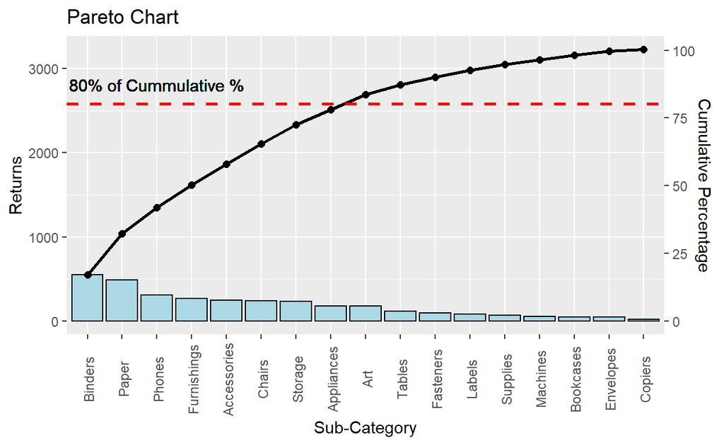

```r
ggplot(freq_cum, aes(x=reorder(`Sub-Category`,-Returns), y = Returns))+
  stat_pareto(point.color = "black",
              point.size = 2,
              line.color = "black",
              line.size = 1,
              bars.fill = "light blue")+
  theme(axis.text.x = element_text(angle=90, vjust=0.6))+
  labs(title = "Pareto Chart", x="Sub-Category") +
  geom_hline(yintercept=0.8*max(freq_cum$cumfreq), linetype="dashed",
                color = "red", size=1) +
  geom_text(aes(3,0.8*max(freq_cum$cumfreq),label = "80% of Cummulative %", vjust = -1))
```

From the Pareto Chart above, we can observe that about top 8 sub-categories (out of 17 sub-categories) contributed to ~80% of the returns.

## 3.0 Age-Sex Pyramid - Singapore Residents

The data used is *[Singapore Residents by Planning Area / Subzone, Age Group, Sex and Floor Area of Residence, June 2021](https://www.singstat.gov.sg/find-data/search-by-theme/population/geographic-distribution/latest-data)* obtained from Singstat.The Age-Sex Pyramid will be able to illustrate the distribution of population by gender across different age groups in Singapore.

### 3.1 Import the Population Data

```r
SGpop<-read_csv("data/respopagesextod2021.csv")
```

### 3.2 Data Preparation

Sum the population by age group and gender.

```r
SGpop_grouped <- SGpop %>%
  group_by(AG,Sex) %>%
  summarise(`Total Pop`=sum(Pop))%>%
  ungroup()

SGpop_grouped
```

```
# A tibble: 38 x 3
   AG       Sex     `Total Pop`
   <chr>    <chr>         <dbl>
 1 0_to_4   Females       87730
 2 0_to_4   Males         91400
 3 10_to_14 Females       97980
 4 10_to_14 Males        102330
 5 15_to_19 Females      100190
 6 15_to_19 Males        105100
 7 20_to_24 Females      115730
 8 20_to_24 Males        122380
 9 25_to_29 Females      139780
10 25_to_29 Males        138790
# ... with 28 more rows
```

Split the Age group to the starting age and ending age of the age group using separate() function in dplyr package and convert them to numeric.This is to enable the sorting of age group by starting age later.

```r
SGpop_grouped2<- separate(data=SGpop_grouped, col=AG,
                          into=c("Starting_Age","Ending_Age"),
                          remove=FALSE, sep ="_to_")
SGpop_grouped2$Starting_Age <- as.numeric(SGpop_grouped2$Starting_Age)
SGpop_grouped2$Ending_Age <-as.numeric(SGpop_grouped2$Ending_Age)
```

### 3.3 Plotting the Age-Sex Pyramid

geom_col() is used to plot the Age-Sex Pyramid based in order to get the horizontal bars.In order to split the gender to two sides, males are plotted on negative x-axis and females are plotted on positive x-axis. To ensure that the age group are sorted numerically, the y axis is sorted based on the starting age of the age group.

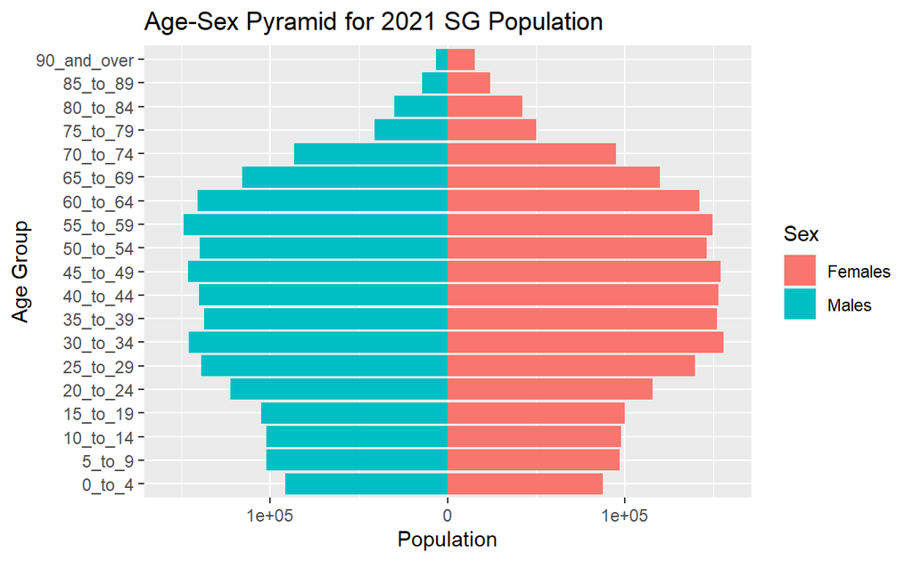

```r
ggplot(SGpop_grouped2, aes(y = reorder(AG,Starting_Age), fill= Sex,
                           x = ifelse(test = Sex =="Males",
                                      yes = -`Total Pop`, no = `Total Pop`)))+
  geom_col(stat="identity")+
  scale_x_continuous(labels = abs, limits = max(SGpop_grouped2$`Total Pop`) * c(-1,1)) +
  labs(title = "Age-Sex Pyramid for 2021 SG Population", x="Population", y ="Age Group")
```